# Life Expectancy Analysis

For Regression Analysis Course, IPB University 2023, our team members:

- Raihan Akbar ([@RaihanAkbar-math](https://github.com/RaihanAkbar-math))
- Daffa Firdaus ([@daffirds](https://github.com/daffirds))
- Anisa Nurhajiza

```r
# libraries
library(readxl)
library(corrplot)
library(knitr)
library(nortest)
library(car)
library(nortest)
library(lmtest)
library(olsrr)
```

### Data Import

```r
data <- read_excel("../data/west-java-life-expectancy-2024.xlsx", skip = 1)[,-1]
data
```

```
## # A tibble: 27 × 7
##        Y     X1    X2    X3     X4    X5    X6
##    <dbl>  <dbl> <dbl> <dbl>  <dbl> <dbl> <dbl>
##  1  75.2  39527  98.4  4.74 14.6    52.1  62.4
##  2  74.6  35659  99.5  2.58  3.47   54.9  57.7
##  3  74.5 121126  99.2  4.37  0.424  69.4  57.3
##  4  74.2  59906  99.5  5.35  8.13   61.2  65.5
##  5  73.8  45921  99.6  7.24  4.61   48.5  58.5
##  6  73.8 107788  99.0  5.21  3.86   30.9  59.8
##  7  73.8  22805  98.6 13.1   2.25   67.2  65.8
##  8  73.7  35590  98.0  7.15  2.40   62.3  60.0
##  9  72.6  32130  94.8 10.7   5.80   69.6  57.8
## 10  72.6  26292  98.2 10.0   2.47   70.8  58.3
## # ℹ 17 more rows
```

### Data Exploration

```r
str(data) #data types
```

```
## tibble [27 × 7] (S3: tbl_df/tbl/data.frame)
##  $ Y : num [1:27] 75.2 74.6 74.5 74.2 73.8 ...
##  $ X1: num [1:27] 39527 35659 121126 59906 45921 ...
##  $ X2: num [1:27] 98.4 99.5 99.2 99.5 99.6 ...
##  $ X3: num [1:27] 4.74 2.58 4.37 5.35 7.24 ...
##  $ X4: num [1:27] 14.568 3.467 0.424 8.128 4.606 ...
##  $ X5: num [1:27] 52.1 54.9 69.4 61.1 48.5 ...
##  $ X6: num [1:27] 62.4 57.7 57.3 65.5 58.5 ...
```

```r
dim(data) #data dimension
```

```
## [1] 27  7
```

```r
summary(data) #data summary
```

```
##        Y               X1               X2              X3
##  Min.   :69.67   Min.   : 20002   Min.   :92.34   Min.   : 2.580
##  1st Qu.:71.47   1st Qu.: 25773   1st Qu.:98.22   1st Qu.: 7.195
##  Median :72.34   Median : 32130   Median :99.18   Median : 8.950
##  Mean   :72.43   Mean   : 43345   Mean   :98.57   Mean   : 8.970
##  3rd Qu.:73.75   3rd Qu.: 45630   3rd Qu.:99.56   3rd Qu.:11.165
##  Max.   :75.19   Max.   :121126   Max.   :99.88   Max.   :13.130
##        X4                X5              X6
##  Min.   : 0.2995   Min.   :30.94   Min.   :55.79
##  1st Qu.: 1.7920   1st Qu.:56.73   1st Qu.:59.03
##  Median : 2.8821   Median :63.48   Median :62.39
##  Mean   : 3.7037   Mean   :62.75   Mean   :64.46
##  3rd Qu.: 5.2752   3rd Qu.:69.51   3rd Qu.:69.67
##  Max.   :14.5679   Max.   :80.77   Max.   :76.89
```

```r
colSums(is.na(data)) #check missing data
```

```
##  Y X1 X2 X3 X4 X5 X6
##  0  0  0  0  0  0  0
```

### Correlation Analysis

```r
# correlation table
corr <- round(cor(data),4)
corr[upper.tri(corr)] <- ""
kable(corr, align = "c")
```

|  | Y | X1 | X2 | X3 | X4 | X5 | X6 |
| --- | --- | --- | --- | --- | --- | --- | --- |
| Y | 1 |  |  |  |  |  |  |
| X1 | 0.3987 | 1 |  |  |  |  |  |
| X2 | -0.145 | 0.063 | 1 |  |  |  |  |
| X3 | -0.5968 | -0.4596 | -0.2836 | 1 |  |  |  |
| X4 | 0.4324 | 0.0887 | -0.1162 | -0.3396 | 1 |  |  |
| X5 | -0.3306 | -0.206 | 0.0546 | 0.2666 | -0.2415 | 1 |  |
| X6 | -0.5963 | -0.3063 | 0.5166 | 0.1523 | 0.0182 | 0.1482 | 1 |

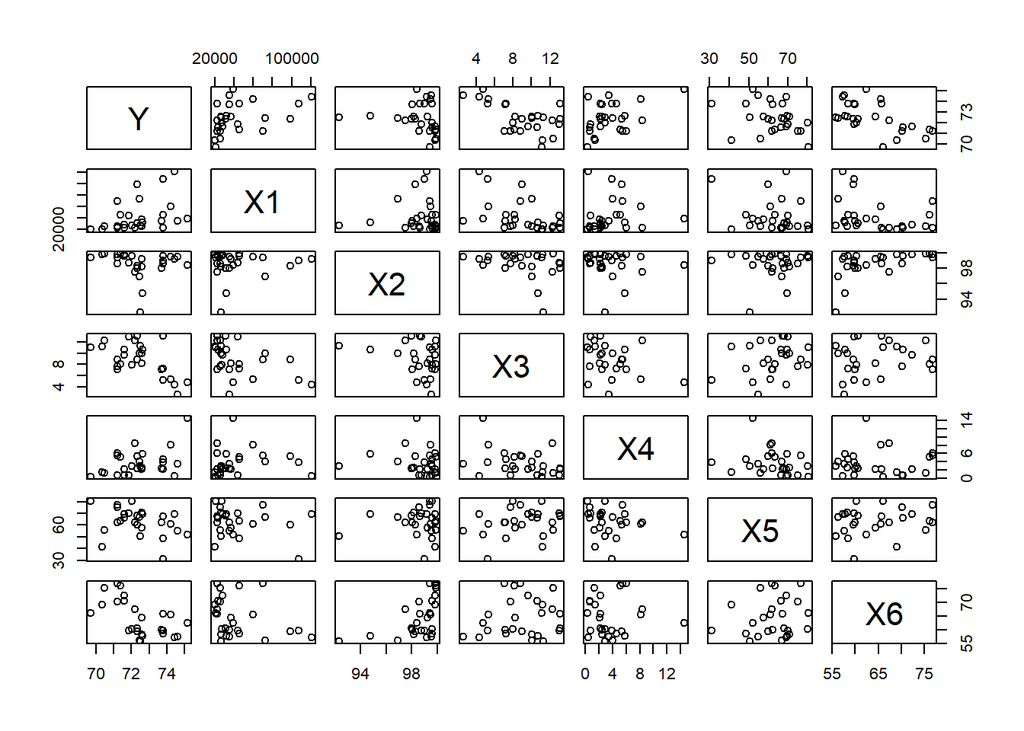

```r
# plot
plot(data, pch = 21)
```

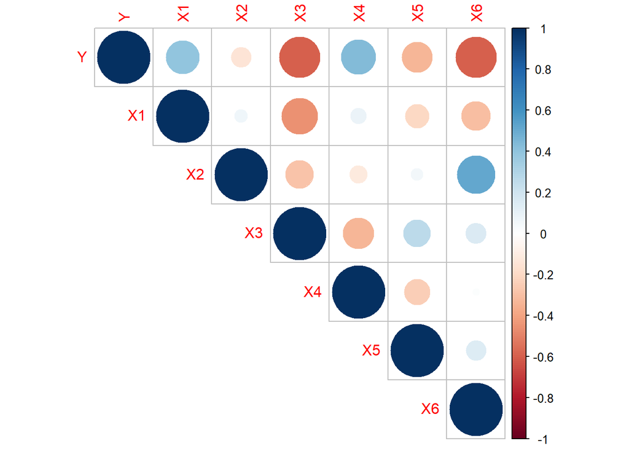

```r
# heat plot
corrplot(cor(data), type="upper")
```

### All variable Regression

```r
model<-lm(Y ~ ., data = data)
model
```

```
##
## Call:
## lm(formula = Y ~ ., data = data)
##
## Coefficients:
## (Intercept)           X1           X2           X3           X4           X5
##   7.343e+01    4.728e-07    8.421e-02   -1.670e-01    1.422e-01   -9.549e-03
##          X6
##  -1.202e-01
```

```r
anova(model)
```

```
## Analysis of Variance Table
##
## Response: Y
##           Df  Sum Sq Mean Sq F value    Pr(>F)
## X1         1  8.0739  8.0739 10.9172 0.0035428 **
## X2         1  1.4757  1.4757  1.9953 0.1731585
## X3         1 14.6630 14.6630 19.8265 0.0002443 ***
## X4         1  1.7310  1.7310  2.3406 0.1417069
## X5         1  0.4788  0.4788  0.6473 0.4305230
## X6         1  9.5770  9.5770 12.9495 0.0017944 **
## Residuals 20 14.7913  0.7396
## ---
## Signif. codes:  0 '***' 0.001 '**' 0.01 '*' 0.05 '.' 0.1 ' ' 1
```

```r
summary(model)
```

```
##
## Call:
## lm(formula = Y ~ ., data = data)
##
## Residuals:
##      Min       1Q   Median       3Q      Max
## -1.61392 -0.22048  0.01115  0.30195  2.45081
##
## Coefficients:
##               Estimate Std. Error t value Pr(>|t|)
## (Intercept)  7.343e+01  1.292e+01   5.684 1.46e-05 ***
## X1           4.728e-07  7.188e-06   0.066  0.94821
## X2           8.421e-02  1.396e-01   0.603  0.55308
## X3          -1.670e-01  7.894e-02  -2.116  0.04710 *
## X4           1.422e-01  6.226e-02   2.285  0.03338 *
## X5          -9.549e-03  1.569e-02  -0.609  0.54956
## X6          -1.202e-01  3.341e-02  -3.599  0.00179 **
## ---
## Signif. codes:  0 '***' 0.001 '**' 0.01 '*' 0.05 '.' 0.1 ' ' 1
##
## Residual standard error: 0.86 on 20 degrees of freedom
## Multiple R-squared:  0.7088, Adjusted R-squared:  0.6214
## F-statistic: 8.113 on 6 and 20 DF,  p-value: 0.0001567
```

$\text{p-value} = 0.0001567 < 0.05$ so $H_0$ rejected.

### Best model selection

#### Best model for each variable size

```r
ols_step_best_subset(model)
```

```
##     Best Subsets Regression
## --------------------------------
## Model Index    Predictors
## --------------------------------
##      1         X3
##      2         X3 X6
##      3         X3 X4 X6
##      4         X3 X4 X5 X6
##      5         X2 X3 X4 X5 X6
##      6         X1 X2 X3 X4 X5 X6
## --------------------------------
##
##                                                   Subsets Regression Summary
## ------------------------------------------------------------------------------------------------------------------------------
##                        Adj.        Pred
## Model    R-Square    R-Square    R-Square     C(p)        AIC       SBIC        SBC       MSEP       FPE       HSP       APC
## ------------------------------------------------------------------------------------------------------------------------------
##   1        0.3562      0.3305      0.2427    21.2133    87.7931     9.3099    91.6806    35.3226    1.4048    0.0545    0.7468
##   2        0.6177      0.5858      0.5338     5.2551    75.7216    -0.7325    80.9049    21.8875    0.8990    0.0352    0.4779
##   3        0.6981      0.6587      0.6117     1.7342    71.3475    -3.0402    77.8267    18.0707    0.7655    0.0303    0.4069
##   4        0.7033      0.6493      0.5786     3.3785    72.8803    -0.7043    80.6553    18.6064    0.8119    0.0326    0.4316
##   5        0.7087      0.6394      0.5702     5.0043    74.3800     1.7092    83.4508    19.1781    0.8611    0.0352    0.4577
##   6        0.7088      0.6214      0.5234     7.0000    76.3741     4.4065    86.7408    20.1831    0.9313    0.0389    0.4951
## ------------------------------------------------------------------------------------------------------------------------------
## AIC: Akaike Information Criteria
##  SBIC: Sawa's Bayesian Information Criteria
##  SBC: Schwarz Bayesian Criteria
##  MSEP: Estimated error of prediction, assuming multivariate normality
##  FPE: Final Prediction Error
##  HSP: Hocking's Sp
##  APC: Amemiya Prediction Criteria
```

#### Backward selection

```r
ols_step_backward_p(model, details = TRUE)
```

```
## Backward Elimination Method
## ---------------------------
##
## Candidate Terms:
##
## 1. X1
## 2. X2
## 3. X3
## 4. X4
## 5. X5
## 6. X6
##
##
## Step   => 0
## Model  => Y ~ X1 + X2 + X3 + X4 + X5 + X6
## R2     => 0.709
##
## Initiating stepwise selection...
##
## Step     => 1
## Removed  => X1
## Model    => Y ~ X2 + X3 + X4 + X5 + X6
## R2       => 0.70872
##
## Step     => 2
## Removed  => X2
## Model    => Y ~ X3 + X4 + X5 + X6
## R2       => 0.70327
##
## Step     => 3
## Removed  => X5
## Model    => Y ~ X3 + X4 + X6
## R2       => 0.69809
##
##
## No more variables to be removed.
##
## Variables Removed:
##
## => X1
## => X2
## => X5
```

```
##
##
##                             Stepwise Summary
## ----------------------------------------------------------------------
## Step    Variable       AIC       SBC       SBIC       R2       Adj. R2
## ----------------------------------------------------------------------
##  0      Full Model    76.374    86.741     4.406    0.70878    0.62141
##  1      X1            74.380    83.451     1.709    0.70872    0.63936
##  2      X2            72.880    80.655    -0.704    0.70327    0.64932
##  3      X5            71.348    77.827    -3.040    0.69809    0.65871
## ----------------------------------------------------------------------
##
## Final Model Output
## ------------------
##
##                         Model Summary
## --------------------------------------------------------------
## R                       0.836       RMSE                0.754
## R-Squared               0.698       MSE                 0.568
## Adj. R-Squared          0.659       Coef. Var           1.127
## Pred R-Squared          0.612       AIC                71.348
## MAE                     0.544       SBC                77.827
## --------------------------------------------------------------
##  RMSE: Root Mean Square Error
##  MSE: Mean Square Error
##  MAE: Mean Absolute Error
##  AIC: Akaike Information Criteria
##  SBC: Schwarz Bayesian Criteria
##
##                                ANOVA
## -------------------------------------------------------------------
##                Sum of
##               Squares        DF    Mean Square      F         Sig.
## -------------------------------------------------------------------
## Regression     35.456         3         11.819    17.727    0.0000
## Residual       15.334        23          0.667
## Total          50.791        26
## -------------------------------------------------------------------
##
##                                   Parameter Estimates
## ----------------------------------------------------------------------------------------
##       model      Beta    Std. Error    Std. Beta      t        Sig      lower     upper
## ----------------------------------------------------------------------------------------
## (Intercept)    80.831         1.568                 51.545    0.000    77.587    84.075
##          X3    -0.199         0.060       -0.412    -3.334    0.003    -0.323    -0.076
##          X4     0.135         0.055        0.302     2.475    0.021     0.022     0.249
##          X6    -0.110         0.024       -0.539    -4.637    0.000    -0.160    -0.061
## ----------------------------------------------------------------------------------------
```

```r
model3 <- lm(Y ~ X3+X4+X6, data = data) #best model
```

### Model Assumptions

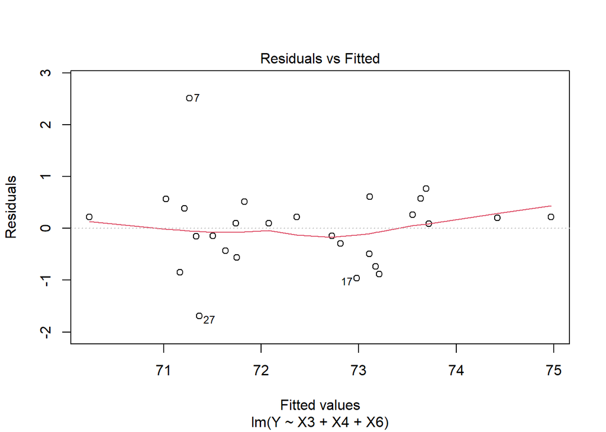

```r
# Assumption exploration
plot(model3,1)                # residuals vs fitted
```

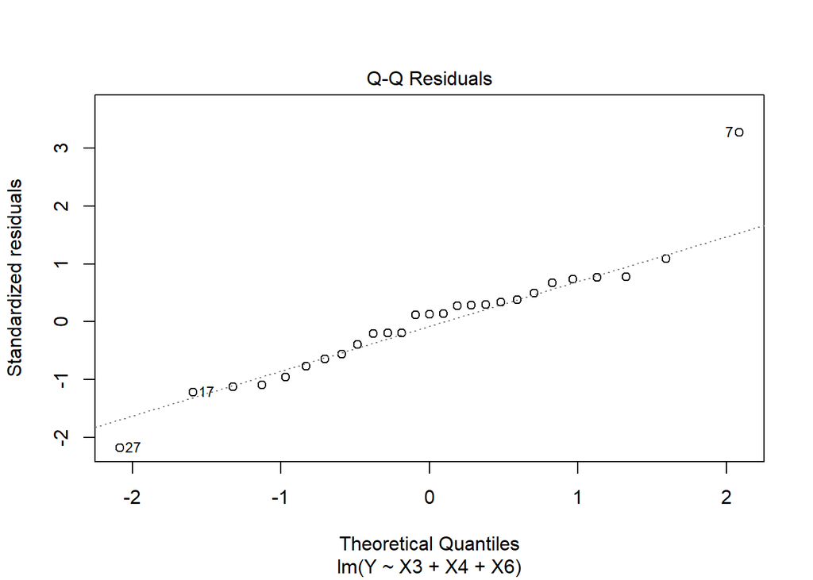

```r
plot(model3,2)                # qq-plot
```

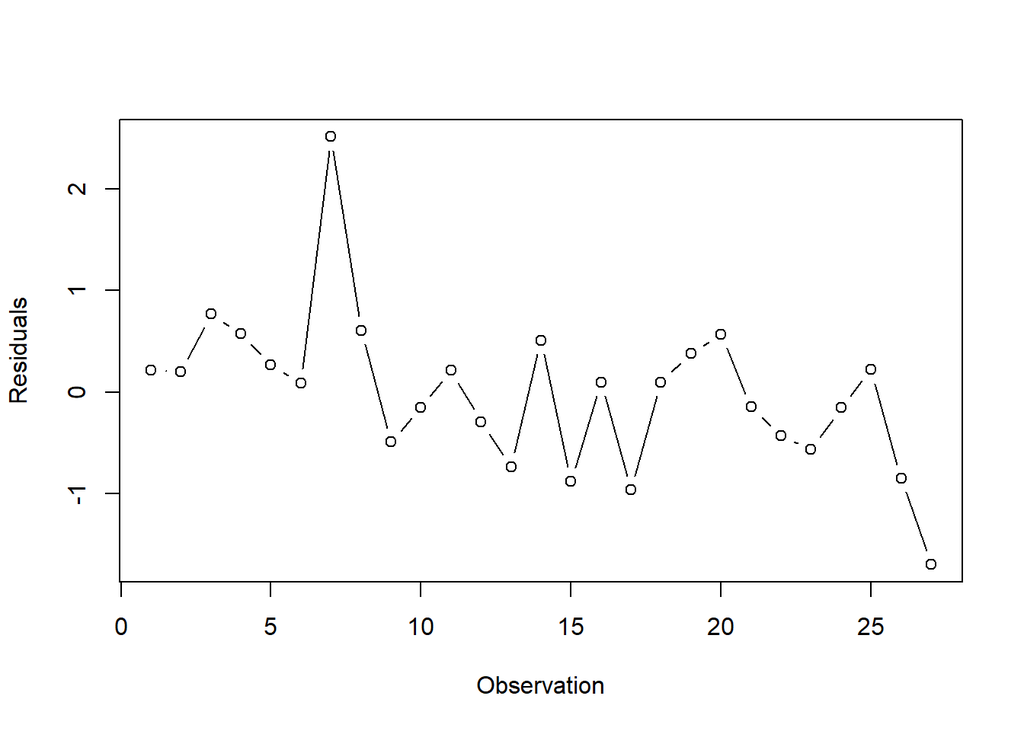

```r
plot(x = 1:dim(data)[1],
     y = model3$residuals,
     type = 'b',
     ylab = "Residuals",
     xlab = "Observation")       # residuals vs obs
```

#### Normality test

```r
lillie.test(model3$residuals) #Kolmogorov-Smirnov test
```

```
##
##  Lilliefors (Kolmogorov-Smirnov) normality test
##
## data:  model3$residuals
## D = 0.14049, p-value = 0.1865
```

**Hypotheses**

$H_0$: The residuals are normally distributed.

$H_1$: The residuals are not normally distributed.

Significance level = 0.05

Test statistic: p-value = 0.1865

Decision: Since the p-value (0.1865) > $\alpha$ (0.05), we fail to reject $H_0$.

Conclusion: At the 95% confidence level, we conclude that the residuals are normally distributed.

#### Multicollinearity test

```r
vif(model3)
```

```
##       X3       X4       X6
## 1.163439 1.136821 1.029582
```

All 3 variables have VIF values less than 10, indicating no presence of multicollinearity.

#### Homoscedasticity test

```r
bptest(model3) #Breusch-Pagan test
```

```
##
##  studentized Breusch-Pagan test
##
## data:  model3
## BP = 2.9494, df = 3, p-value = 0.3995
```

**Hypotheses**

$H_0$: The variance is homogeneous

$H_1$: The variance is not homogeneous

Significance level: 0.05

Conclusion: At the 95% confidence level, we conclude that the variance is homogeneous (the homoscedasticity assumption is satisfied).

#### Autocorrelation Test

```r
bgtest(model3, order=3) #Breusch-Godfrey test
```

```
##
##  Breusch-Godfrey test for serial correlation of order up to 3
##
## data:  model3
## LM test = 2.1293, df = 3, p-value = 0.546
```

The LM test statistic is 2.1293 with a p-value of 0.546 and 3 degrees of freedom. The decision is to accept $H_0$, meaning that there is no autocorrelation among the residuals at the 5% significance level.

### Conclusion

The best regression equation obtained in this study is:
$$\hat{Y}=80.8312−0.1990 X_3+0.1354 X_4−0.1104 X_6$$
with

$\hat{Y}=$ Life expectancy prediction (years)

$X_3=$ Poverty rate (%)

$X_4=$ Complete immunization rate (%)

$X_6=$ Education index (unit)